# Waffle charts

## Or why you should never, ever use a pie chart.

Pie charts are the devil. They are an instant F in this class. I’ll give you an example of why.

What’s the racial breakdown of journalism majors at UNL?

Here it is in a pie chart:

```r
library(dplyr)
```

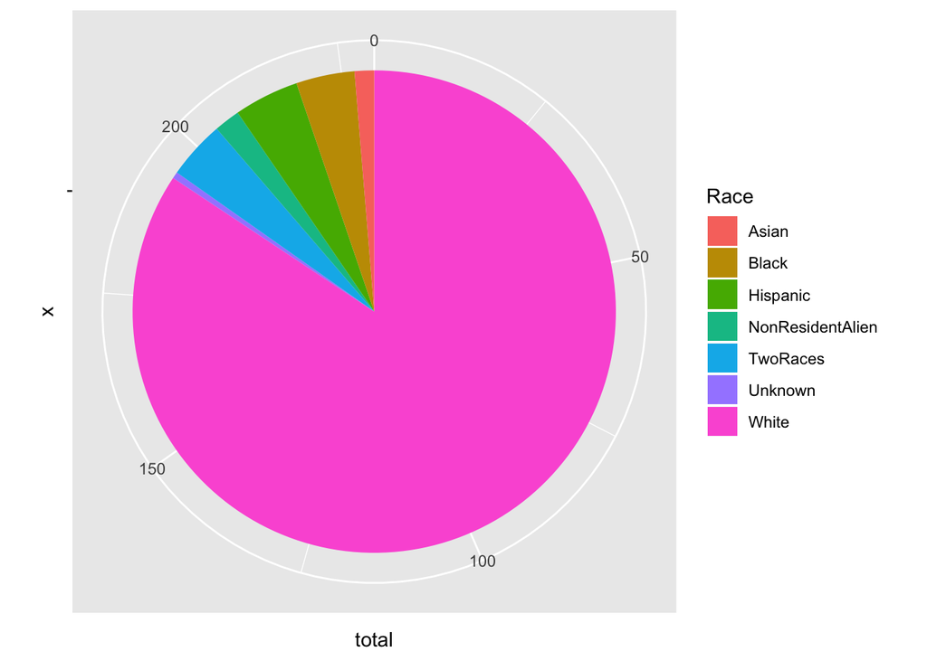

```r
library(ggplot2)

enrollment <- read.csv("~/Dropbox/JOUR407-Data-Visualization/Data/collegeenrollment.csv")

jour <- filter(enrollment, MajorName == "Journalism")

jdf <- jour %>%
group_by(Race) %>%
summarize(
       total=sum(Count)) %>%
select(Race, total) %>%
filter(total != 0)

ggplot(jdf, aes(x="", y=total, fill=Race)) + geom_bar(width = 1, stat = "identity") + coord_polar("y", start=0)
```

You can see, it’s pretty white. But … what about beyond that? How carefully can you evaluate angles and area?

Not well.

So let’s introduce a better way: The Waffle Chart. Some call it a square pie chart. I personally hate that. Waffles it is.

First, install the library:

`install.packages('waffle')`

Now load it:

```r
library(waffle)
```

Let’s look at the offensive numbers from Saturday’s Nebraska v. Wisconsin football game. Nebraska lost 41-24, but Wisconsin gained only 15 yards more than Nebraska did. You can find the [official stats on the NCAA’s website](https://www.ncaa.com/game/football/fbs/2018/10/06/nebraska-wisconsin/team-stats).

I’m going to make two vectors for each team and record rushing yards and passing yards.

```r
nu <- c("Rushing"=111, "Passing"=407)
wi <- c("Rushing"=370, "Passing"=163)
```

So what does the breakdown of Nebraska’s night look like? How balanced was the offense?

The waffle library can break this down in a way that’s easier on the eyes than a pie chart. We call the library, add the data, specify the number of rows, give it a title and an x value label, and to clean up a quirk of the library, we’ve got to specify colors.

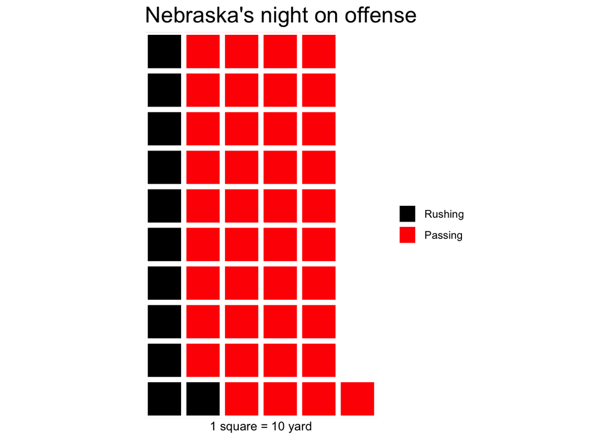

```r
waffle(nu/10, rows = 10, title="Nebraska's night on offense", xlab="1 square = 10 yard", colors = c("black", "red"))
```

So what does it look like if we compare the two teams. Do do that – and I am not making this up – you have to create a waffle iron. Get it? Waffle charts? Iron?

```r
iron(
 waffle(nu/10, rows = 10, title="Nebraska's night on offense", xlab="1 square = 10 yards", colors = c("black", "red")),
 waffle(wi/10, rows = 10, title="Wisconsin's night on offense", xlab="1 square = 10 yards", colors = c("black", "red"))
)
```

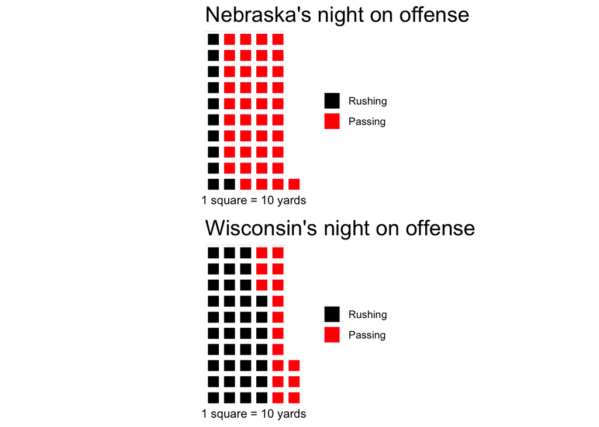

### Assignment

Compare Nebraska and Wisconsin using a Waffle chart using something other than what I’ve done above.

[Here’s the library’s documentation](https://github.com/hrbrmstr/waffle). [Here’s the stats from the game](https://www.ncaa.com/game/football/fbs/2018/10/06/nebraska-wisconsin/team-stats).

Turn in your notebook with your waffle chart by the end of class. It must contain these two things:

- Your waffle chart
- A written narrative of what it says. What does your waffle chart say about how that game turned out?

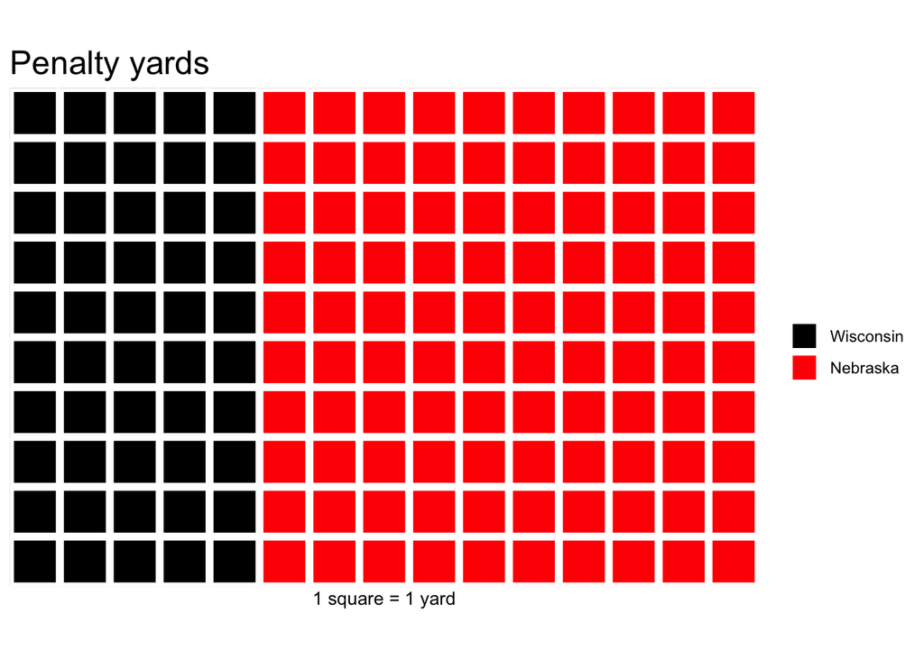

```r
penalties <- c('Wisconsin'=50, 'Nebraska'=100)

waffle(penalties, rows=10, title="Penalty yards", xlab="1 square = 1 yard", colors=c("black", "red"))
```

Not good, Bob. Not good.